# Set 4 of Exercises

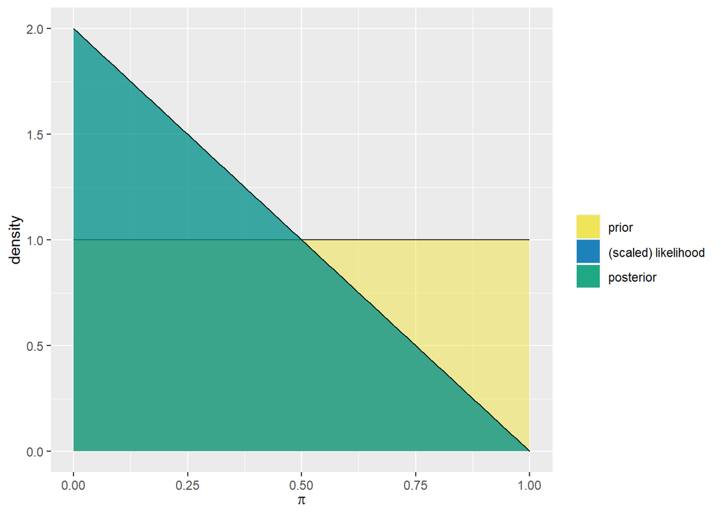

```r
plot_beta_binomial(pr_alfa,pr_beta,y,n)
```

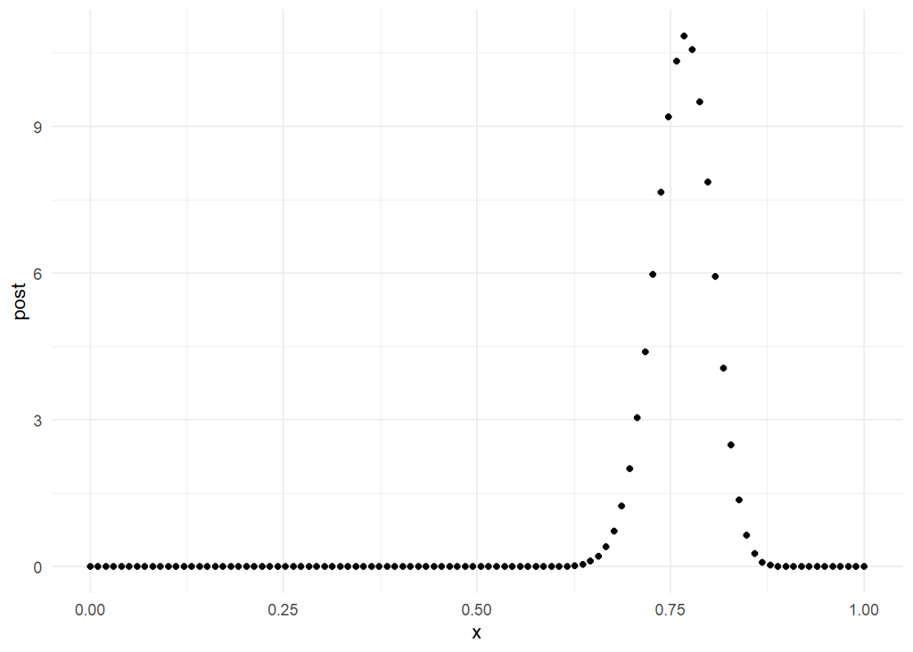

```r
## Set alpha and beta for Beta (1,1)
pr_alfa <- 1
pr_beta <- 1
## Set trials data
y <- 100
n <- 130

x <- seq(0,1,length.out=100)

c_plot <- tibble(x=x, post=dbeta(x, pr_alfa+y,pr_beta+n-y)) |> ggplot(aes(x,post)) + geom_point() + theme_minimal()

c_plot
```

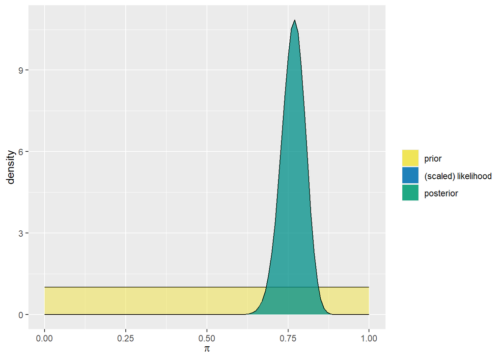

```r
plot_beta_binomial(pr_alfa,pr_beta,y,n)
```

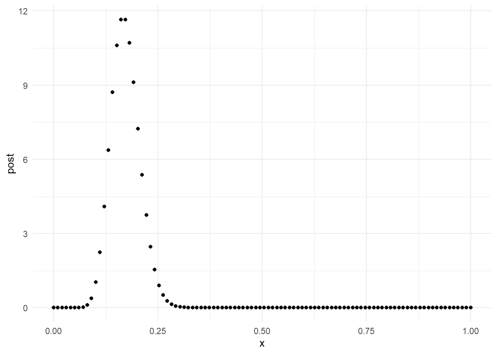

```r
## Set alpha and beta for Beta (1,1)
pr_alfa <- 1
pr_beta <- 1
## Set trials data
y <- 20
n <- 120

x <- seq(0,1,length.out=100)

d_plot <- tibble(x=x, post=dbeta(x, pr_alfa+y,pr_beta+n-y)) |> ggplot(aes(x,post)) + geom_point() + theme_minimal()

d_plot
```

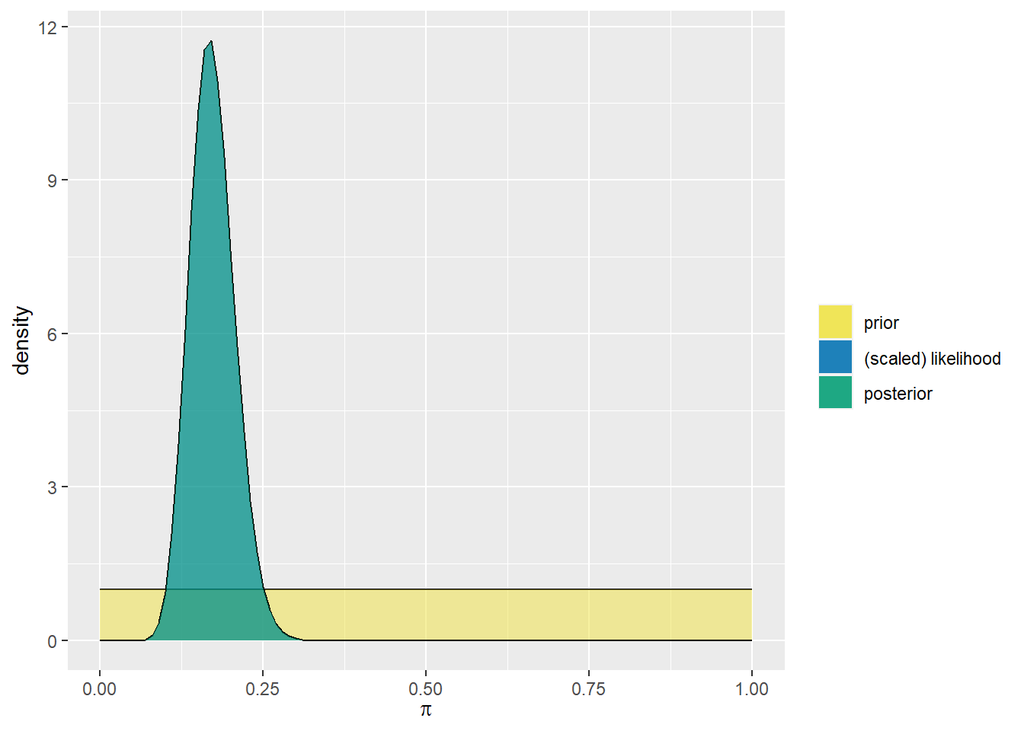

```r
plot_beta_binomial(pr_alfa,pr_beta,y,n)
```

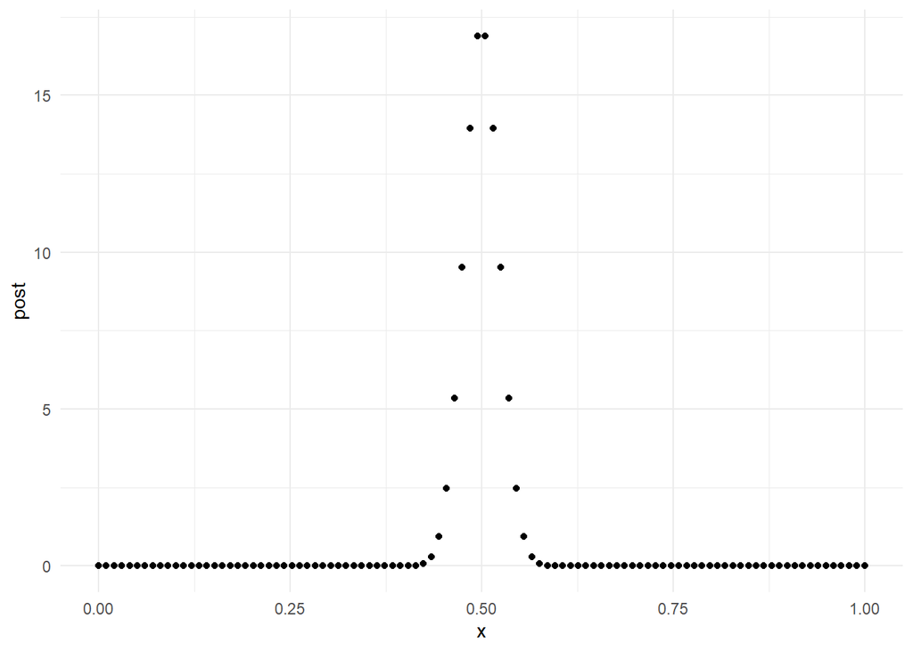

```r
## Set alpha and beta for Beta (1,1)
pr_alfa <- 1
pr_beta <- 1
## Set trials data
y <- 234
n <- 468

x <- seq(0,1,length.out=100)

e_plot <- tibble(x=x, post=dbeta(x, pr_alfa+y,pr_beta+n-y)) |> ggplot(aes(x,post)) + geom_point() + theme_minimal()

e_plot
```

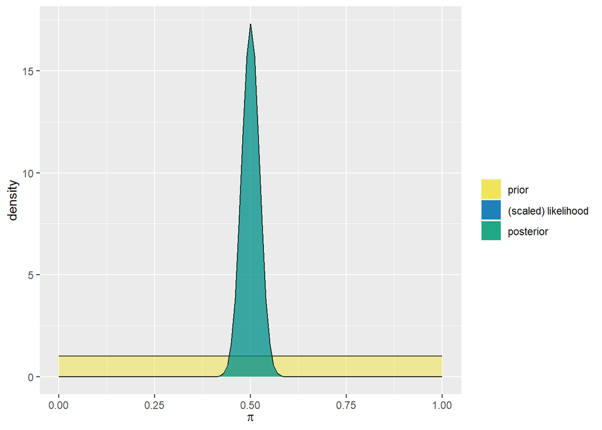

```r
plot_beta_binomial(pr_alfa,pr_beta,y,n)
```

Basically, with more data we have slimmer distributions.

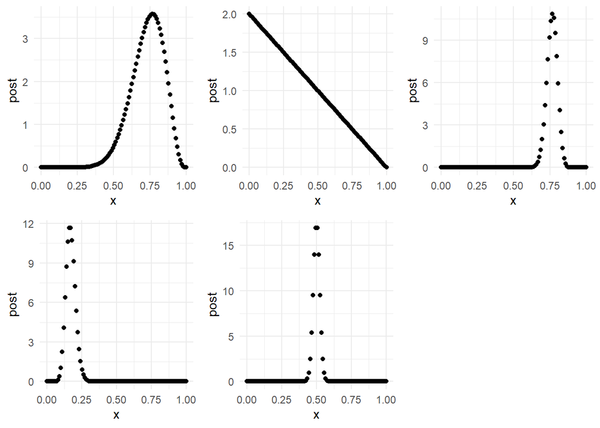

```r
ggarrange(a_plot, b_plot, c_plot, d_plot, e_plot, ncol=3, nrow=2)
```

## 4.12

Posteriors with this beta look rather similar than the uniform modeel with the exception of plot b that has a very tiny n. In this model, the posterior is very similar to the prior. Thus, in contrast to the prior in 4.11, this prior is more informative.

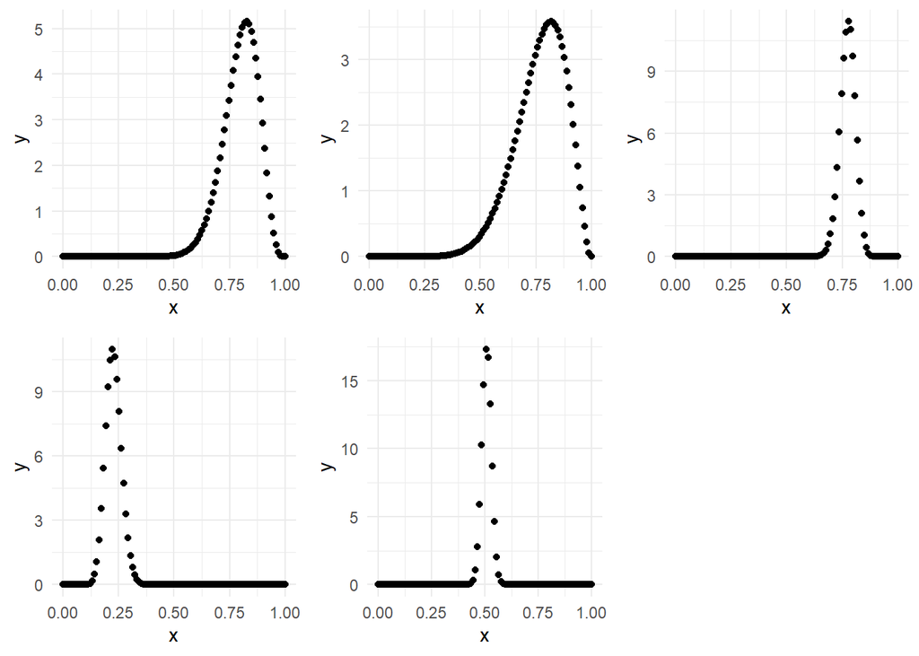

```r
## Set alpha and beta for Beta (10,2)
pr_alfa <- 10
pr_beta <- 2
x <- seq(0,1,length.out=100)

y_list <- as.list(c(10,0,100,20,234))
n_list <- as.list(c(13,1,130,120,468))


plot_list = list()
for (i in 1:5){
    dfp <- tibble(x=x,y=dbeta(x, pr_alfa+y_list[[i]][1], pr_beta+n_list[[i]][1]-y_list[[i]][1]))

p <- dfp |> ggplot(aes(x,y)) + geom_point() + theme_minimal()

      plot_list[[i]] <- p
  }

ggarrange(plot_list[[1]],
          plot_list[[2]],
          plot_list[[3]],
          plot_list[[4]],
          plot_list[[5]],
          ncol=3,nrow=2)
```

## 4.13

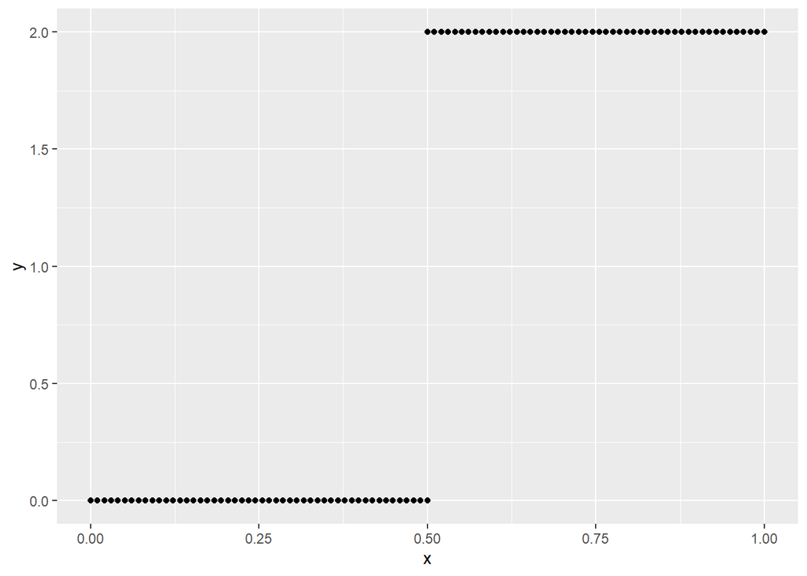

```r
x1 <- seq(0,.5,length.out=50)
x2 <- seq(.5,1,length.out=50)
y_2 <- rep(2,50)
y_0 <- rep(0,50)

stub <- tibble(x=x1, y=y_0) |> add_row(x=x2,y=y_2)


stub |> ggplot(aes(x,y))  + geom_point()
```

2. The politician thinks that the probability that his approval rating is 0 is between 0 and less than 50%. He also thinks that the probability of having an approval rating od 2 is between 50% and les than 100%.

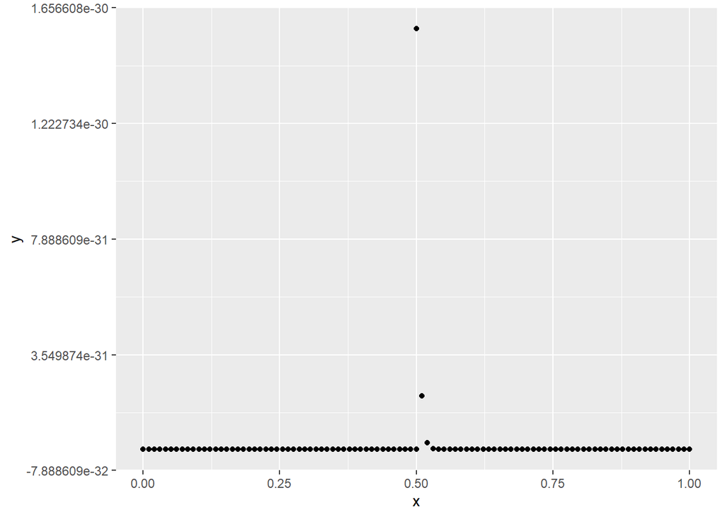

```r
## f(pi|y=0) approximates f(pi) L(pi|y=0)

tibble(x=x1,y=rep(0,50)) |> add_row(x=x2, y=2*(choose(100,0))*x2^0*(1-x2)^(100)) |> ggplot(aes(x,y)) + geom_point()
```

## 4.15

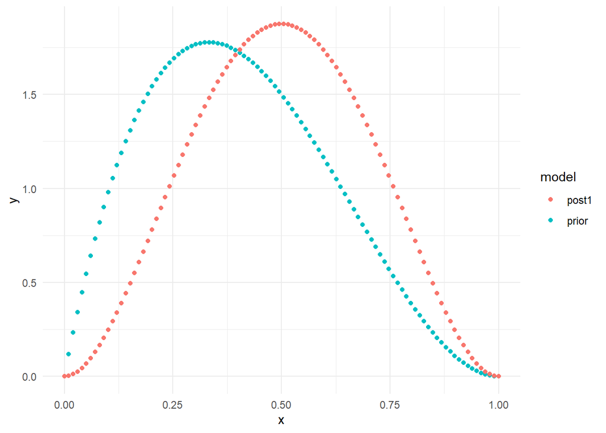

```r
x <- seq(0,1,length.out=100)

y <- 1
n <- 1


prior <- tibble(x=x,y=dbeta(x,2,3), model=rep("prior",100))

models <- prior |> add_row(x=x, y=dbeta(x,2+y,3+n-y), model=rep("post1",100))


models |> ggplot(aes(x,y,col=model)) + geom_point() + theme_minimal() +  scale_color_discrete()
```

b.

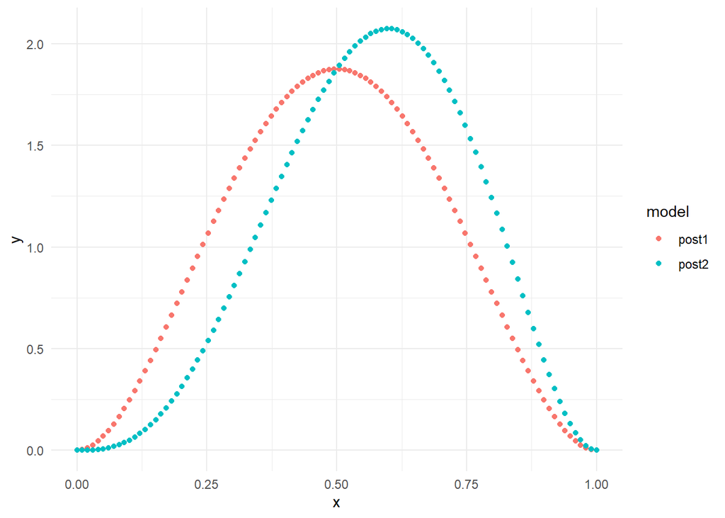

```r
up_a <- 2 + y
up_b <- 3+n-y

y <- 1
n <- 1


models <- models |> add_row(x=x, y=dbeta(x,up_a+y,up_b+n-y), model=rep("post2",100))


models |> filter(model=="post1" | model=="post2") |> ggplot(aes(x,y,col=model)) + geom_point() + theme_minimal() +  scale_color_discrete()
```

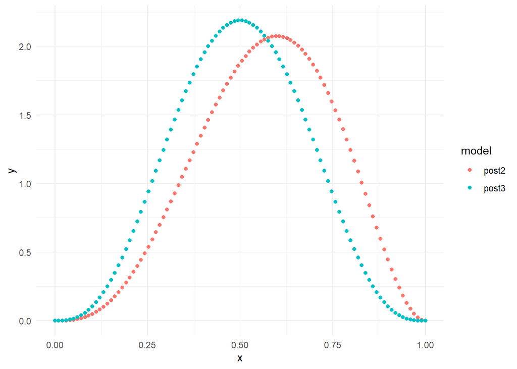

```r
up_a <- up_a + y
up_b <- up_b+n-y

y <- 0
n <- 1


models <- models |> add_row(x=x, y=dbeta(x,up_a+y,up_b+n-y), model=rep("post3",100))


models |> filter(model=="post3" | model=="post2") |> ggplot(aes(x,y,col=model)) + geom_point() + theme_minimal() +  scale_color_discrete()
```

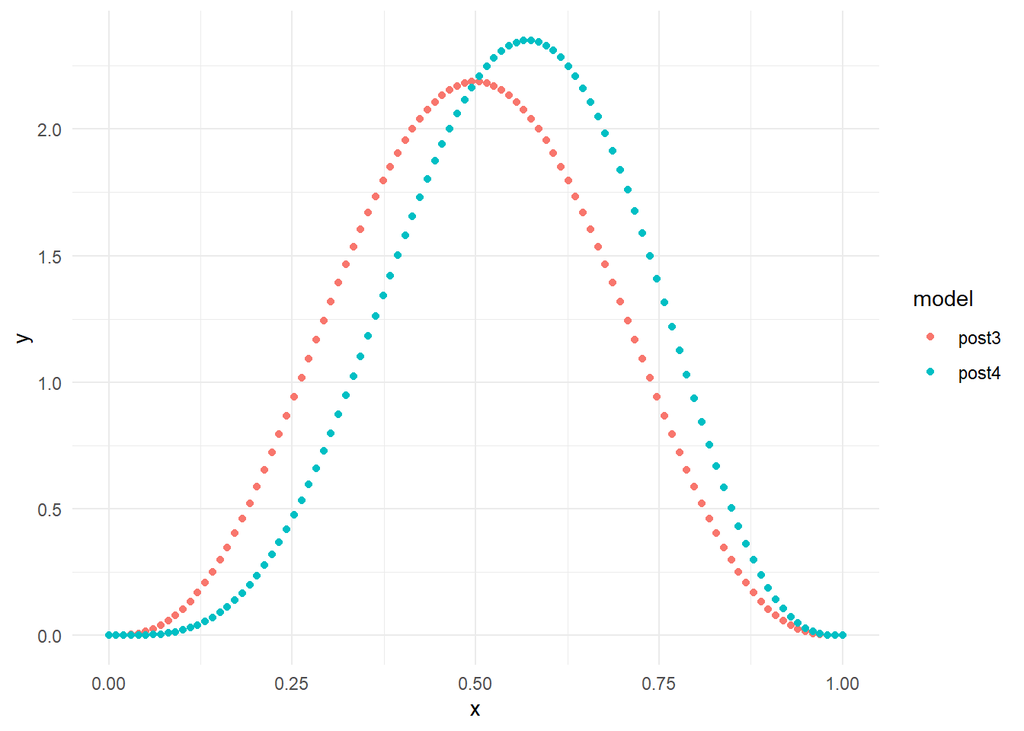

```r
up_a <- up_a + y
up_b <- up_b+n-y

y <- 1
n <- 1


models <- models |> add_row(x=x, y=dbeta(x,up_a+y,up_b+n-y), model=rep("post4",100))


models |> filter(model=="post3" | model=="post4") |> ggplot(aes(x,y,col=model)) + geom_point() + theme_minimal() +  scale_color_discrete()
```

This plot illustrates how the posteriors updated with each piece of new information.

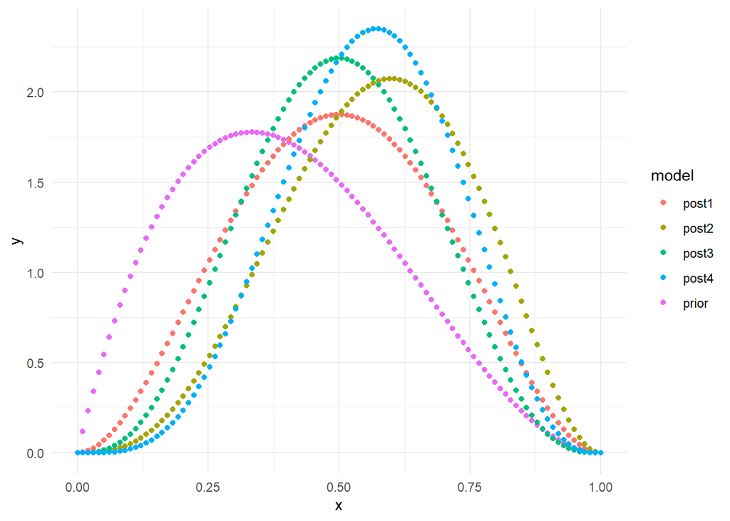

```r
models |> ggplot(aes(x,y,color=model)) + geom_point() + theme_minimal()
```

## 4.16

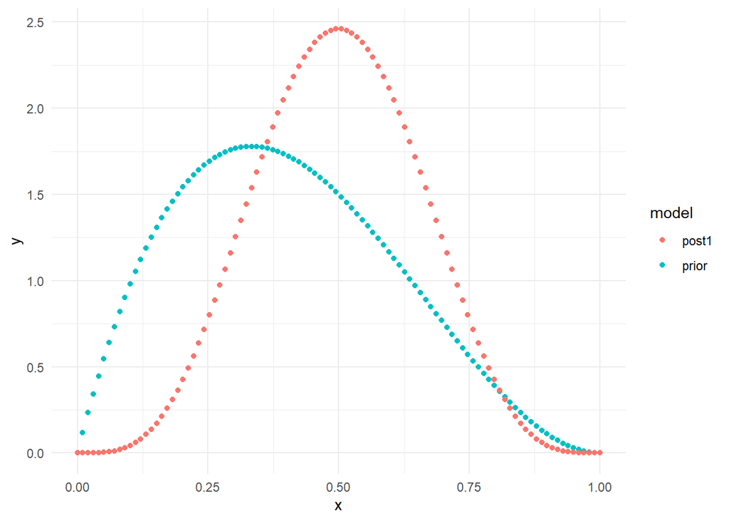

```r
x <- seq(0,1,length.out=100)

y <- 3
n <- 5


prior <- tibble(x=x,y=dbeta(x,2,3), model=rep("prior",100))

models2 <- prior |> add_row(x=x, y=dbeta(x,2+y,3+n-y), model=rep("post1",100))


models2 |> ggplot(aes(x,y,col=model)) + geom_point() + theme_minimal() +  scale_color_discrete()
```

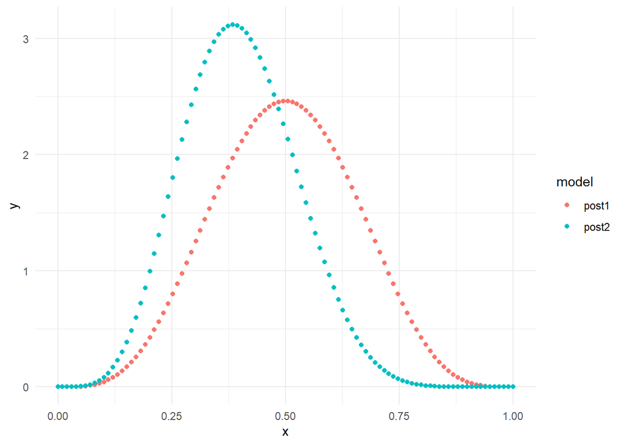

```r
up_a <- 2 + y
up_b <- 3+n-y

y <- 1
n <- 5


models2 <- models2 |> add_row(x=x, y=dbeta(x,up_a+y,up_b+n-y), model=rep("post2",100))


models2 |> filter(model=="post1" | model=="post2") |> ggplot(aes(x,y,col=model)) + geom_point() + theme_minimal() +  scale_color_discrete()
```

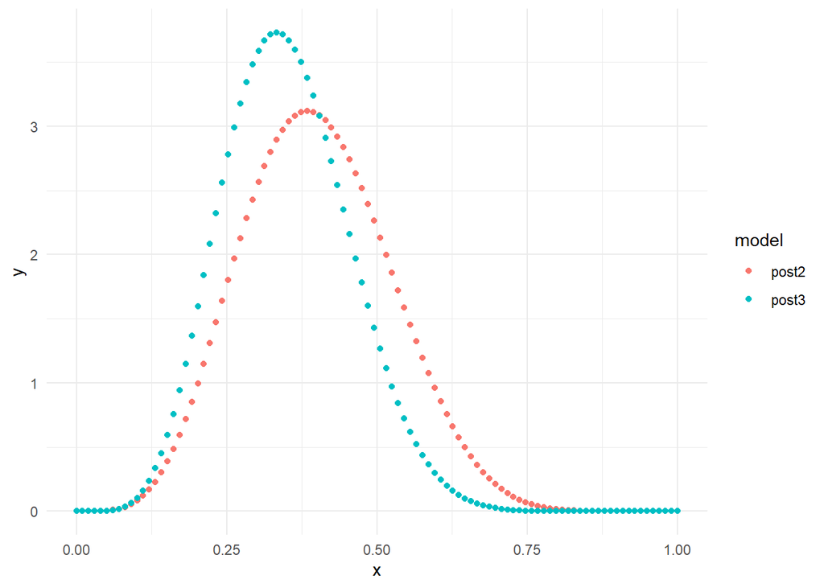

```r
up_a <- up_a + y
up_b <- up_b+n-y

y <- 1
n <- 5


models2 <- models2 |> add_row(x=x, y=dbeta(x,up_a+y,up_b+n-y), model=rep("post3",100))


models2 |> filter(model=="post3" | model=="post2") |> ggplot(aes(x,y,col=model)) + geom_point() + theme_minimal() +  scale_color_discrete()
```

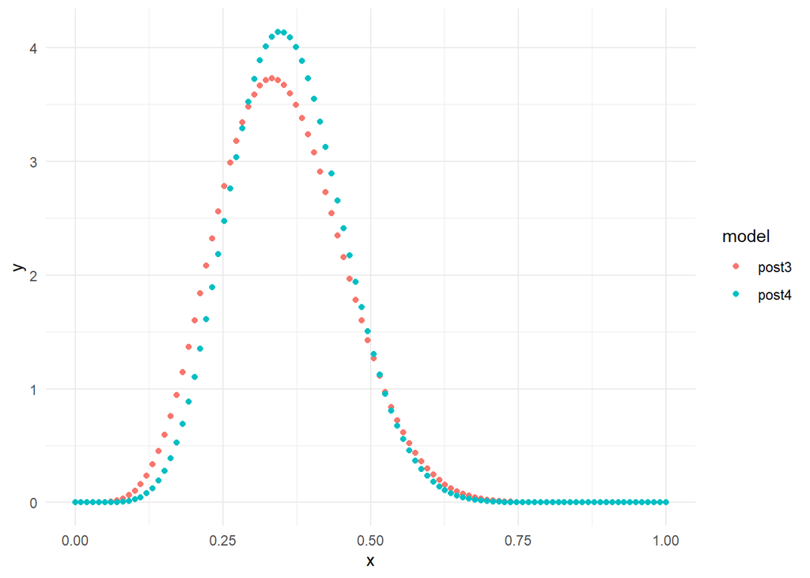

```r
up_a <- up_a + y
up_b <- up_b+n-y

y <- 2
n <- 5


models2 <- models2 |> add_row(x=x, y=dbeta(x,up_a+y,up_b+n-y), model=rep("post4",100))


models2 |> filter(model=="post3" | model=="post4") |> ggplot(aes(x,y,col=model)) + geom_point() + theme_minimal() +  scale_color_discrete()
```

This plot illustrates how the posteriors updated with each piece of new information.

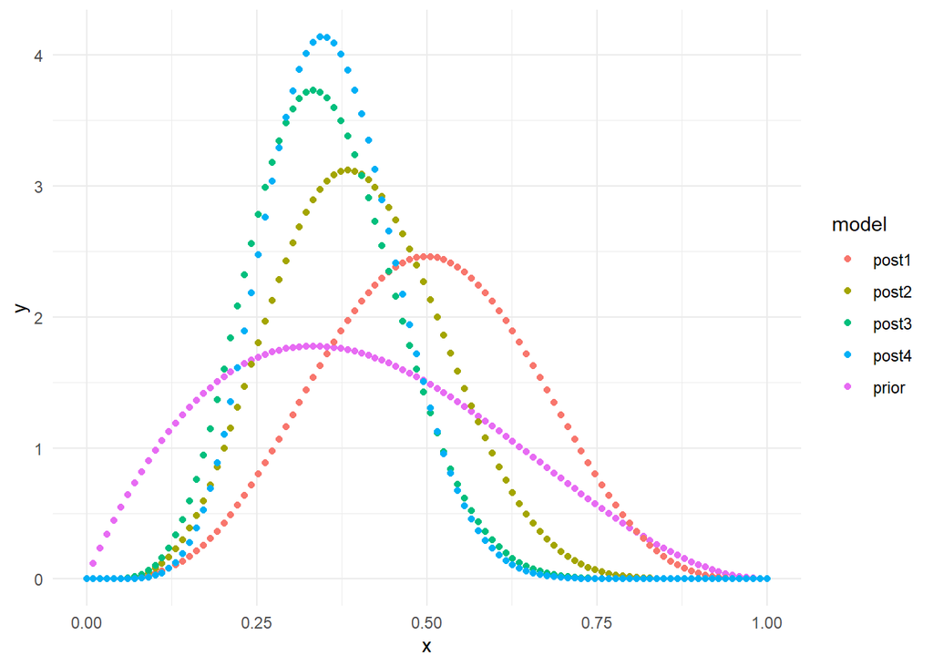

```r
models2 |> ggplot(aes(x,y,col=model)) + geom_point() + theme_minimal()
```

## 4.17

The probability that a user will click on the new ad when shown is slightly above the 50% chance. However, there is a relatively high level of uncertainty: plausible values range from .35 to .75

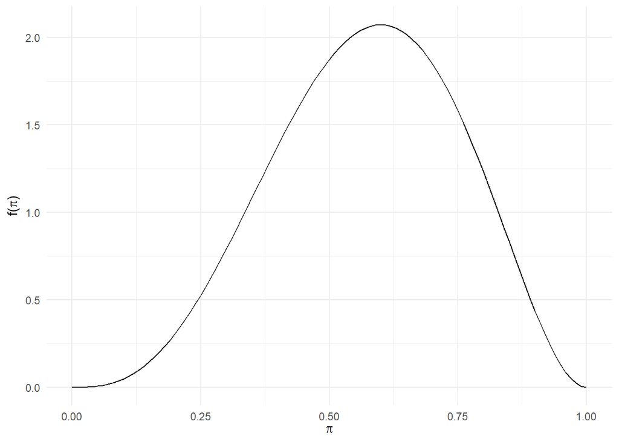

```r
plot_beta(4,3) + theme_minimal()
```

2. Here, 0 is the prior that all the three employees share. As we can see, employee 3 has the most different posterior because he/she collected more data, in contrast to his coworkers. More powerful data leads to more defined posteriors.

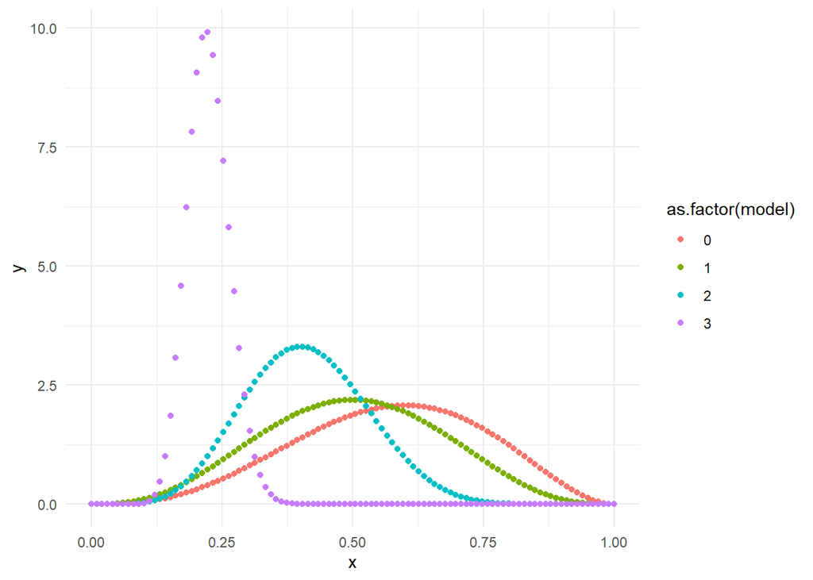

```r
x <- seq(0,1,length.out=100)

y <- as.list(c(0,3,20))
n <- as.list(c(1,10,100))


models3 <- tibble(x=x,y=dbeta(x,4,3), model=rep(0,100))

for(i in 1:3){

  models3 <- models3 |> add_row(x=x, y=dbeta(x,4+y[[i]][1],3+n[[i]][1]-y[[i]][1]),
                                model=rep(i,100))
}

models3 |>  ggplot(aes(x,y,col=as.factor(model))) + geom_point() + theme_minimal()
```

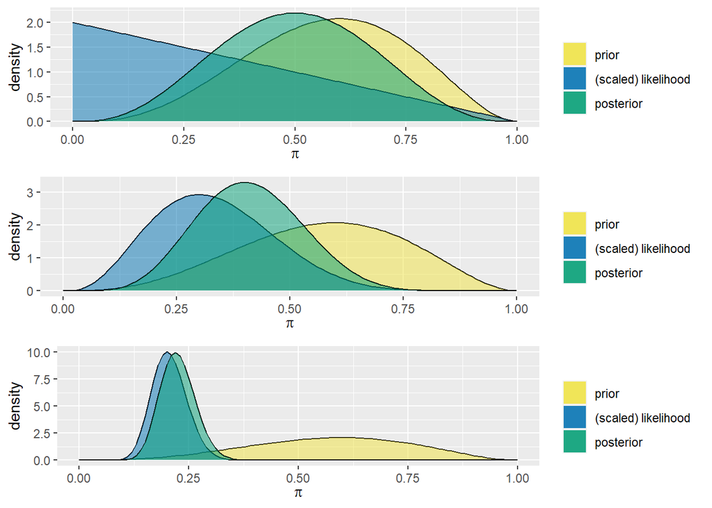

```r
x <- seq(0,1,length.out=100)

y <- as.list(c(0,3,20))
n <- as.list(c(1,10,100))


models3 <- tibble(x=x,y=dbeta(x,4,3), model=rep(0,100))


plot_list = list()
for(i in 1:3){

  p <- plot_beta_binomial(4,3,y[[i]][1],n[[i]][1])
   plot_list[[i]] <- p
    }

ggarrange(plot_list[[1]],
          plot_list[[2]],
          plot_list[[3]],
          ncol=1, nrow=3)
```

4. The posterior model of worker 1 has a higher standard deviation than the one from worker 3. The reason is that worker three tested the hypothesis with more people, so he diminished the uncertainty of his final posterior.

```r
a <- 4
b <- 3
y <- as.list(c(0,3,20))
n <- as.list(c(1,10,100))

all_posteriors = tibble(mean=as.numeric(), mode=as.numeric(), var=as.numeric(), sd=as.numeric(), worker=as.numeric())

for(i in 1:3){
    all_posteriors <- all_posteriors |>  add_row(summarize_beta(a+y[[i]][1],b+n[[i]][1]-y[[i]][1]), worker=i)
}

all_posteriors
```

```
## # A tibble: 3 x 5
##    mean  mode     var     sd worker
##   <dbl> <dbl>   <dbl>  <dbl>  <dbl>
## 1 0.5   0.5   0.0278  0.167       1
## 2 0.412 0.4   0.0135  0.116       2
## 3 0.224 0.219 0.00161 0.0401      3
```

## 4.18

1. I’ll use the same coding strategy I used above.

First, I use the initial Beta (4,3) as prior, and the first trial as the observed data.

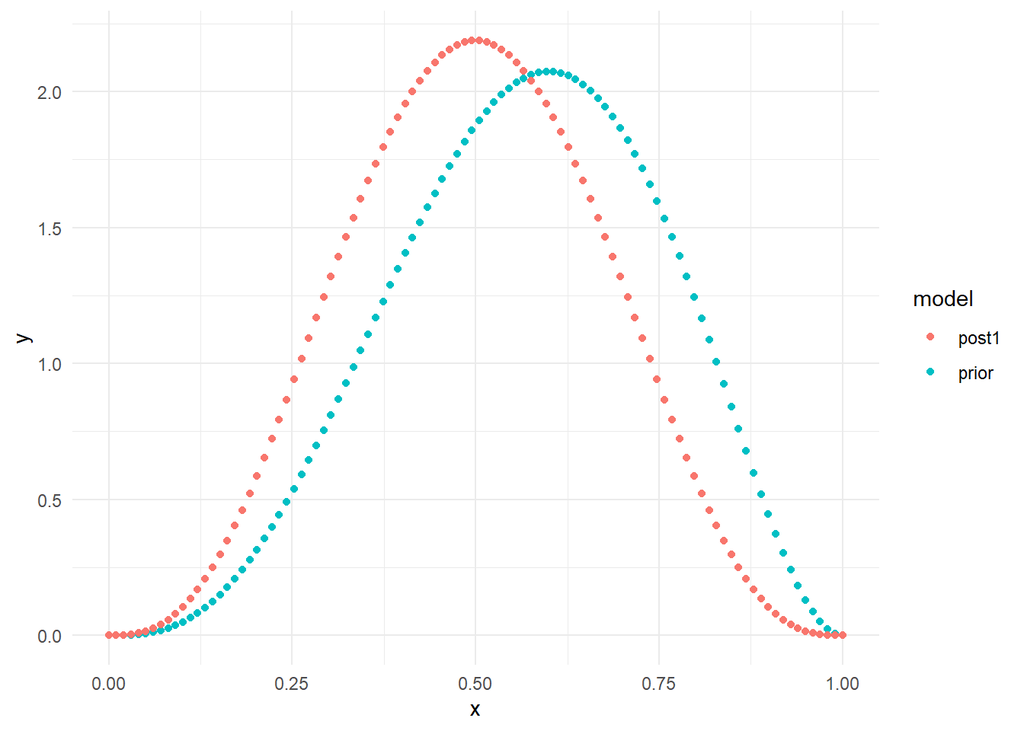

```r
a <- 4
b <- 3

x <- seq(0,1,length.out=100)

y <- 0
n <- 1


prior <- tibble(x=x,y=dbeta(x,a,b), model=rep("prior",100))

seq_emplo <- prior |> add_row(x=x, y=dbeta(x,a+y,b+n-y), model=rep("post1",100))

seq_emplo |> ggplot(aes(x,y,col=model)) + geom_point() + theme_minimal() +  scale_color_discrete()
```

Now we have a new prior, which is post1 in the plot above. Using the new observation, we can update this prior as follows:

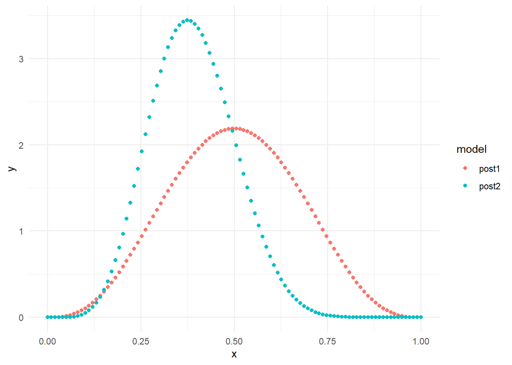

```r
up_a <- a + y
up_b <- b+n-y

y <- 3
n <- 10


seq_emplo <- seq_emplo  |> add_row(x=x, y=dbeta(x,up_a+y,up_b+n-y), model=rep("post2",100))


seq_emplo  |> filter(model=="post1" | model=="post2") |> ggplot(aes(x,y,col=model)) + geom_point() + theme_minimal() +  scale_color_discrete()
```

Updated posterior on day 3:

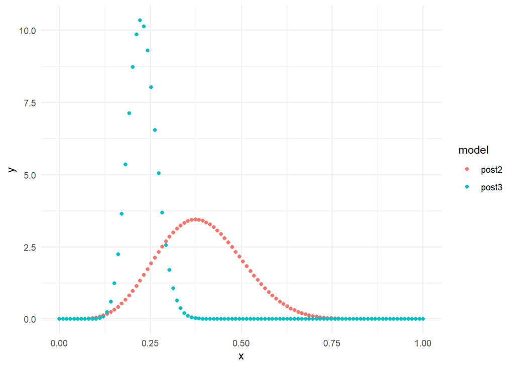

```r
up_a <- up_a + y
up_b <- up_b+n-y

y <- 20
n <- 100


seq_emplo <- seq_emplo  |> add_row(x=x, y=dbeta(x,up_a+y,up_b+n-y), model=rep("post3",100))


seq_emplo  |> filter(model=="post3" | model=="post2") |> ggplot(aes(x,y,col=model)) + geom_point() + theme_minimal() +  scale_color_discrete()
```

2. We can see that the understanding of the new employee about pi slowly moves to the left in the first two days. With the new data in day 3, however, the posterior significantly shifts even more to the left with high levels of certainty.

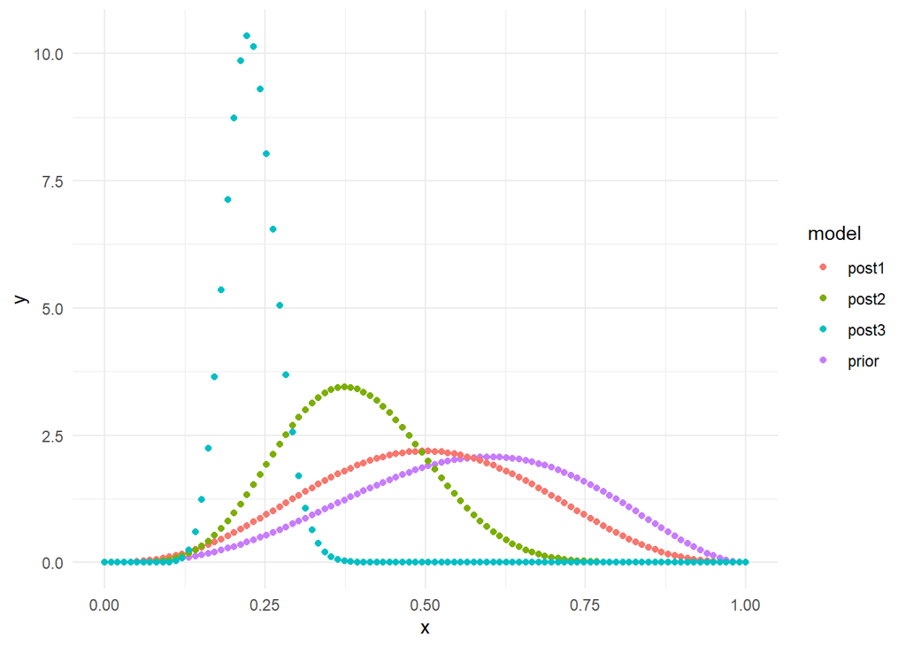

```r
seq_emplo |> ggplot(aes(x,y,col=model)) + geom_point() + theme_minimal()
```

3. I will sum the y’s and n’s from each day for this exercise.

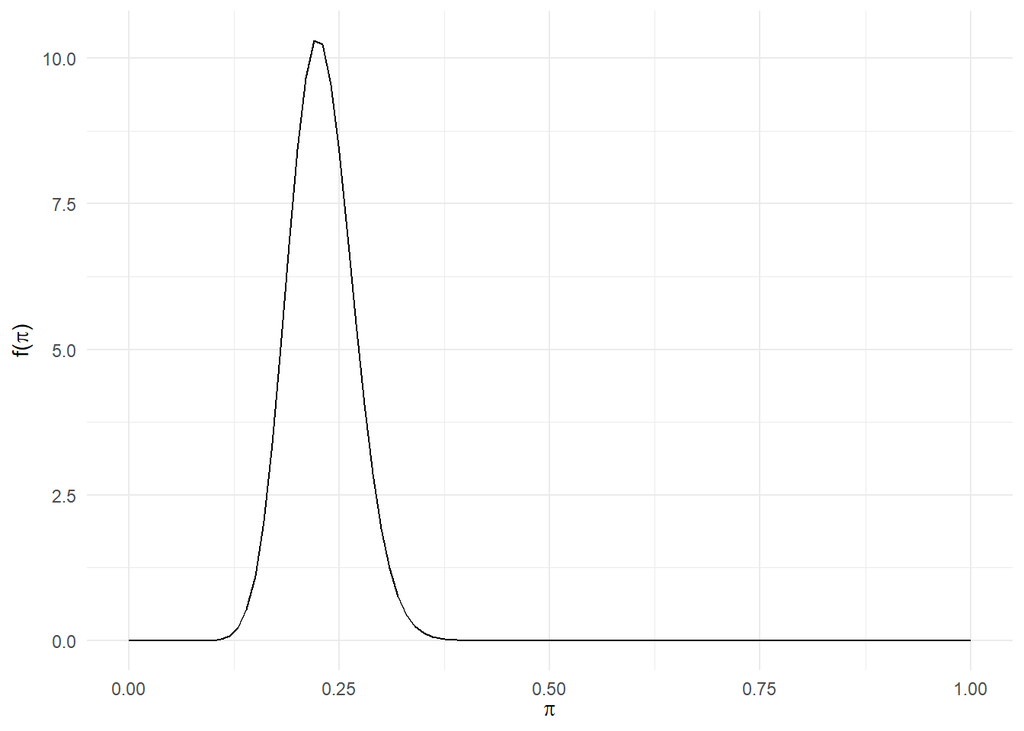

```r
ns <- sum(c(1,10,100))
ys <- sum(c(0,3,20))

plot_beta(4+ys,3+ns-ys) + theme_minimal()
```

In line with the argument about how the order doesn’t matter for the final posterior, we observe that this plot looks exactly the same as the plot of the sequentially-obtained posterior.

## 4.19

```r
data(bechdel, package = "bayesrules")
```

```r
a <- 1
b <- 1

bechdel |> filter(year==1980) |> group_by(binary) |> summarize(prop_pass=n())
```

```
## # A tibble: 2 x 2
##   binary prop_pass
##   <chr>      <int>
## 1 FAIL          10
## 2 PASS           4
```

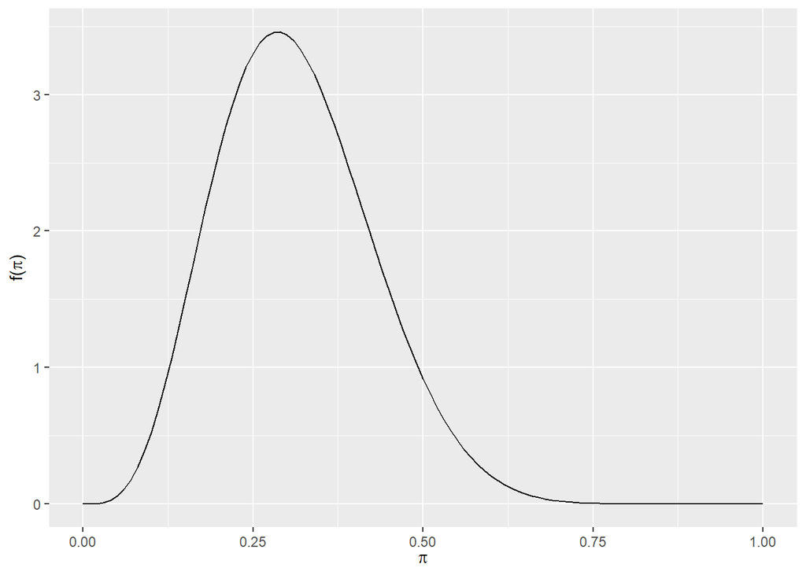

```r
plot_beta(a+4,b-4+14)
```

```r
summarize_beta(a+4,b-4+14)
```

```
##     mean      mode        var        sd
## 1 0.3125 0.2857143 0.01263787 0.1124183
```

2. The new prior is the posterior from a)

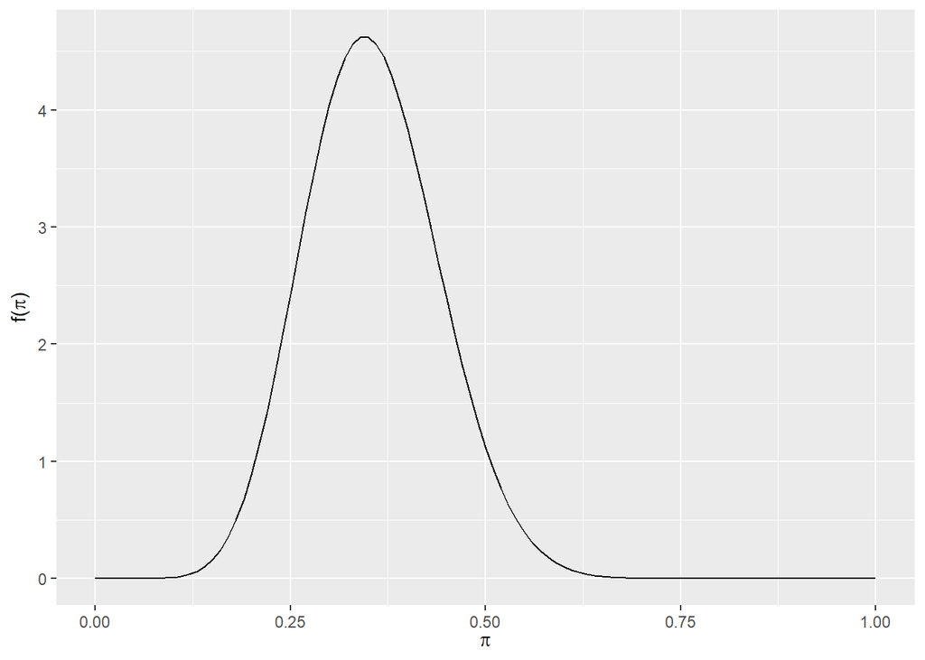

```r
a <- a+4
b <- b+14-4

p1990 <-  bechdel |> filter(year==1990) |> group_by(binary) |> summarize(prop_pass=n())

y <- p1990$prop_pass[p1990$binary=="PASS"]
n <- sum(p1990$prop_pass)


plot_beta(a+y,b+n-y)
```

```r
summarize_beta(a+y,b+n-y)
```

```
##        mean      mode         var         sd
## 1 0.3548387 0.3448276 0.007154006 0.08458136
```

3. Same

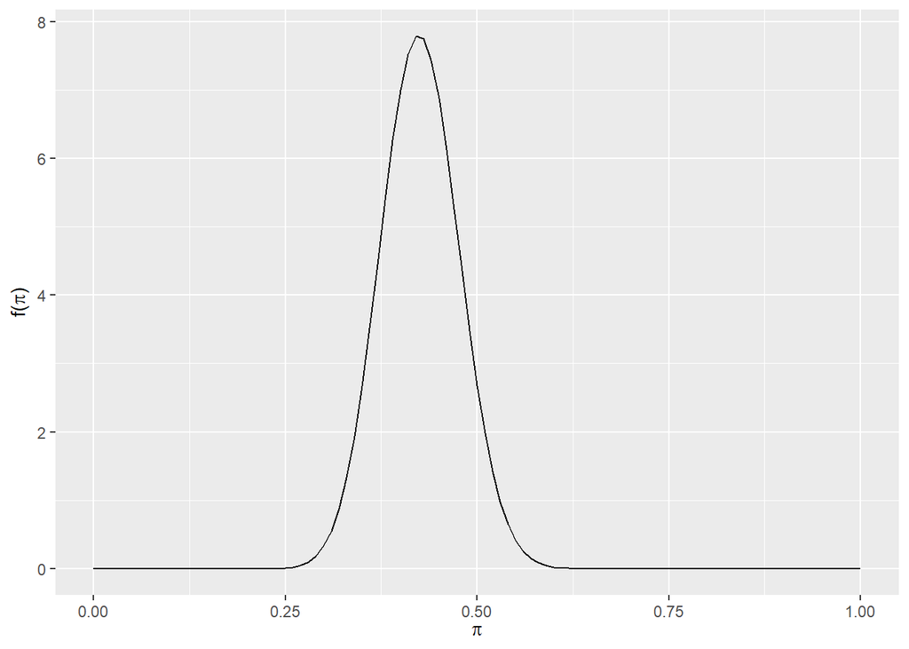

```r
# Prior

a <- a+y
b <- b+n-y

# New information
pyear <-  bechdel |> filter(year==2000) |> group_by(binary) |> summarize(prop_pass=n())
y <- pyear$prop_pass[pyear$binary=="PASS"]
n <- sum(pyear$prop_pass)

# New posterior
plot_beta(a+y,b+n-y)
```

```r
summarize_beta(a+y,b+n-y)
```

```
##        mean     mode         var         sd
## 1 0.4255319 0.423913 0.002573205 0.05072677
```

4. Jenna’s posterior is the same as John’s last posterior. This is yet another prove that order doesn’t matter.

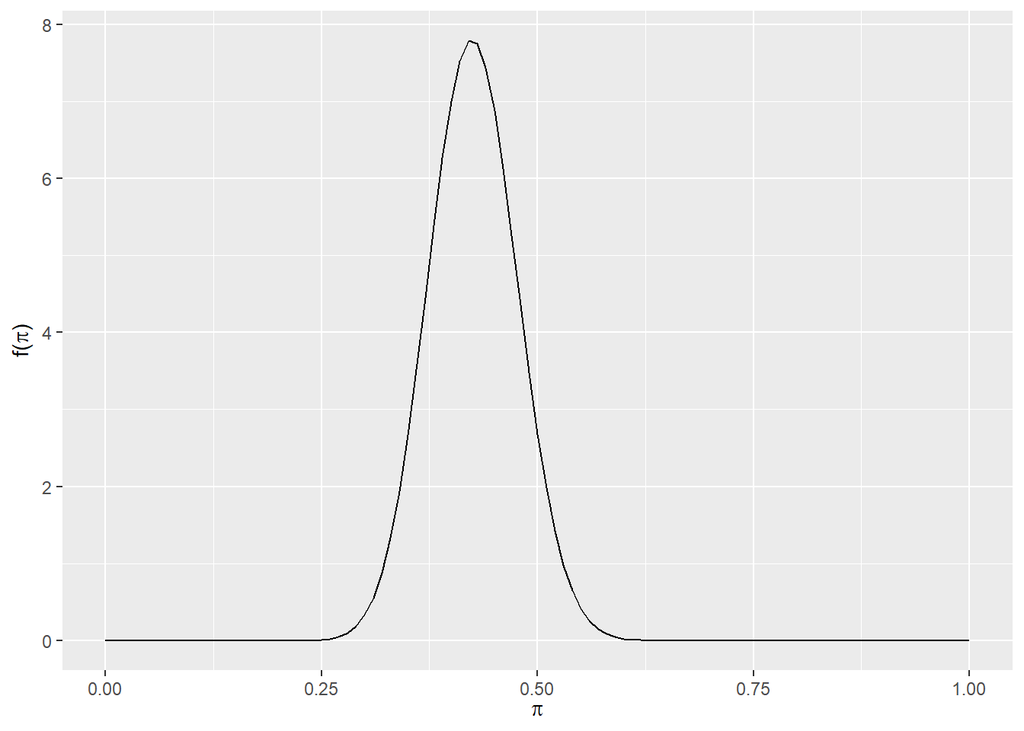

```r
a <- 1
b <- 1

pyear <- bechdel |> filter(year==1980 | year==1990 | year==2000) |> group_by(binary) |> summarize(prop_pass=n())
y <- pyear$prop_pass[pyear$binary=="PASS"]
n <- sum(pyear$prop_pass)

# New posterior
plot_beta(a+y,b+n-y)
```

```r
summarize_beta(a+y,b+n-y)
```

```
##        mean     mode         var         sd
## 1 0.4255319 0.423913 0.002573205 0.05072677
```

## 4.20

A frequentist approach would model reality according to the data obtained a certain moment in time, disregarding the data previously collected on the matter. However, sometimes they are similar in that sometimes A Bayesian model might include a “frequentist” prior which is the uniform beta model: beta(1,1). In this case, frequentist and bayesian analysis would look the same.